# Review, Libraries and Loading Data

Savet Hong

March 27, 2018

## Review Objects

- Atomic
- Vector
- Matrix
- Array
- List

# Visualize Objects

## Atomic as a dot/coin

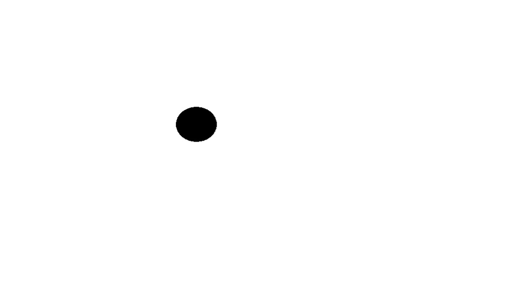

## Vector as a line/bar

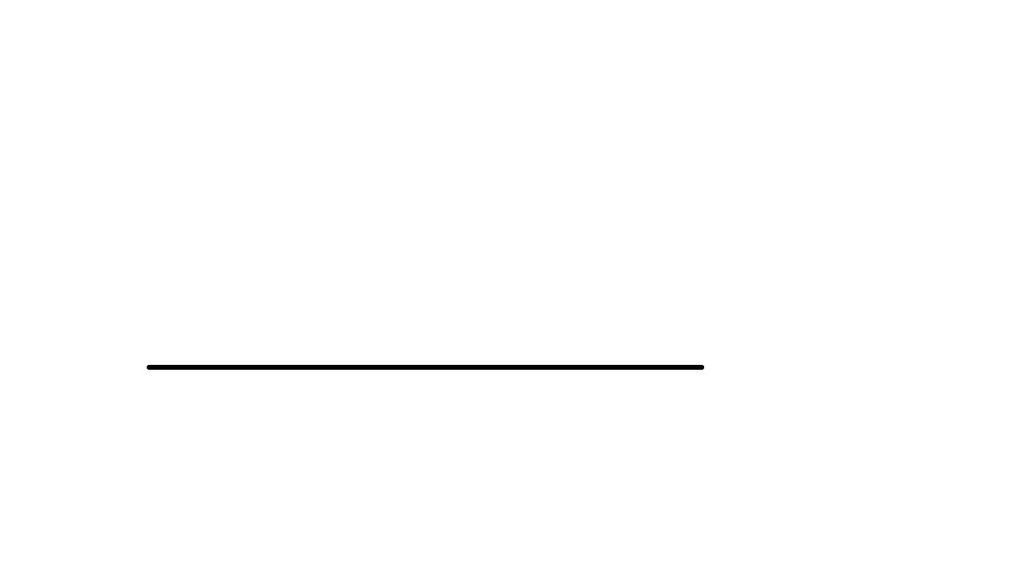

## Matrix as a square/paper

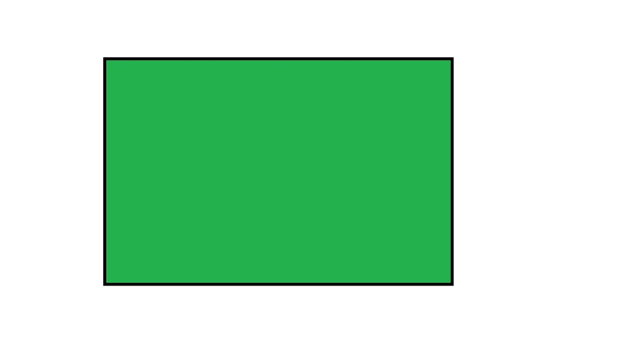

## Array as a cube/box

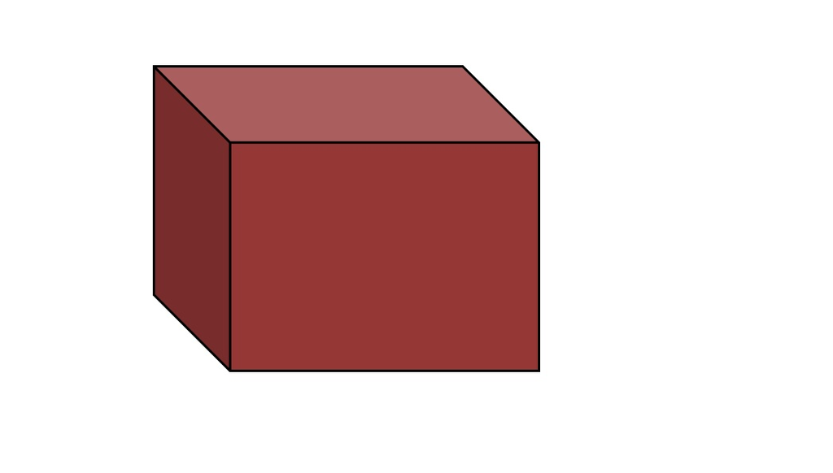

## List as a container/chest

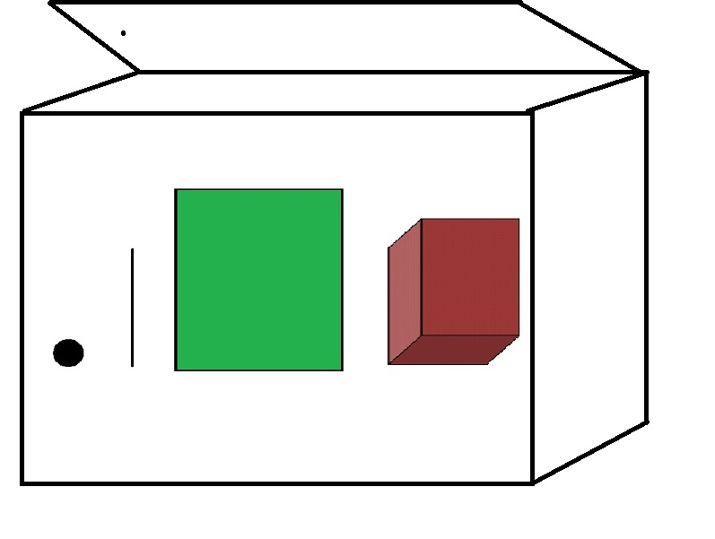

## Indexing

```r
mat <- matrix(1:24,4,6)
arr <- array(1:40, dim = c(4,5,2))

mat[3,4]
```

```
## [1] 15
```

- What is the index for arr containing the value 36?
- arr[4,4,2]

## Working with List

- Load list of Homework 1 objects into environment
- What does it look like?

  ```r
  str(hw1_dat)
  ```

  ```
  ## List of 5
  ##  $ mat      : int [1:2, 1:5] 1 2 3 4 5 6 7 8 9 10
  ##  $ mat2     : int [1:2, 1:5] 11 12 13 14 15 16 17 18 19 20
  ##  $ nums_fact: Factor w/ 2 levels "two","four": 1 1 2 1 1 2 1 1 2 1 ...
  ##  $ scale    : num 3
  ##  $ vec      : int [1:5] 1 2 3 4 5
  ```

  ```r
  hw1_dat
  ```

  ```
  ## $mat
  ##      [,1] [,2] [,3] [,4] [,5]
  ## [1,]    1    3    5    7    9
  ## [2,]    2    4    6    8   10
  ##
  ## $mat2
  ##      [,1] [,2] [,3] [,4] [,5]
  ## [1,]   11   13   15   17   19
  ## [2,]   12   14   16   18   20
  ##
  ## $nums_fact
  ##  [1] two  two  four two  two  four two  two  four two  two  four two  two
  ## [15] four
  ## Levels: two four
  ##
  ## $scale
  ## [1] 3
  ##
  ## $vec
  ## [1] 1 2 3 4 5
  ```

## Extract Objects from list

- Get the first object in hw1_dat

  ```r
  hw1_dat[1]
  ```

  ```
  ## $mat
  ##      [,1] [,2] [,3] [,4] [,5]
  ## [1,]    1    3    5    7    9
  ## [2,]    2    4    6    8   10
  ```

  ```r
  hw1_dat[[1]]
  ```

  ```
  ##      [,1] [,2] [,3] [,4] [,5]
  ## [1,]    1    3    5    7    9
  ## [2,]    2    4    6    8   10
  ```

  ```r
  hw1_dat$mat
  ```

  ```
  ##      [,1] [,2] [,3] [,4] [,5]
  ## [1,]    1    3    5    7    9
  ## [2,]    2    4    6    8   10
  ```

## Extract elements from object in list

- Get the element in the 2nd row and 3rd column from the first object in hw1_dat

  ```r
  hw1_dat$mat[2,3]
  ```

  ```
  ## [1] 6
  ```

  ```r
  hw1_dat[[1]][2,3]
  ```

  ```
  ## [1] 6
  ```

# Library

## Library packages

- What is include in the base package?

  ```r
  library(help = "base")
  ```

## Other Library packages

- Packages contains funtions and data not included in the base package
- Programers develop packages for specific fields or simplifying their coding process
- Beware that a function in one package can mask a function in another package

  ```r
  library(dplyr)
  ```

## Tidyverse

What is tidyverse?

```r
library(tidyverse)
```

- Collection of packages for data analysis and visualization where the packages share similar structure, concepts, and coding logic.

## Special Library Loading

- Call a specific function from a package for a specific code
- Use the format
  - package::function()
  - e.g., dplyr::filter()

# Getting Data Into and Out of R

## Import Files

- What type of data files do we normally work with?
  - Excel
  - Stata
- Libraries for Excel
  - library(utils)*
  - library(readr)
  - library(readxl)
  - library(openxlsx)

  *Do not need to load this package.
- Libraries for Stata
  - library(foreign)
  - library(readstata13)
- Other packages exist to read other data format

## What functions are available in the foreign package?

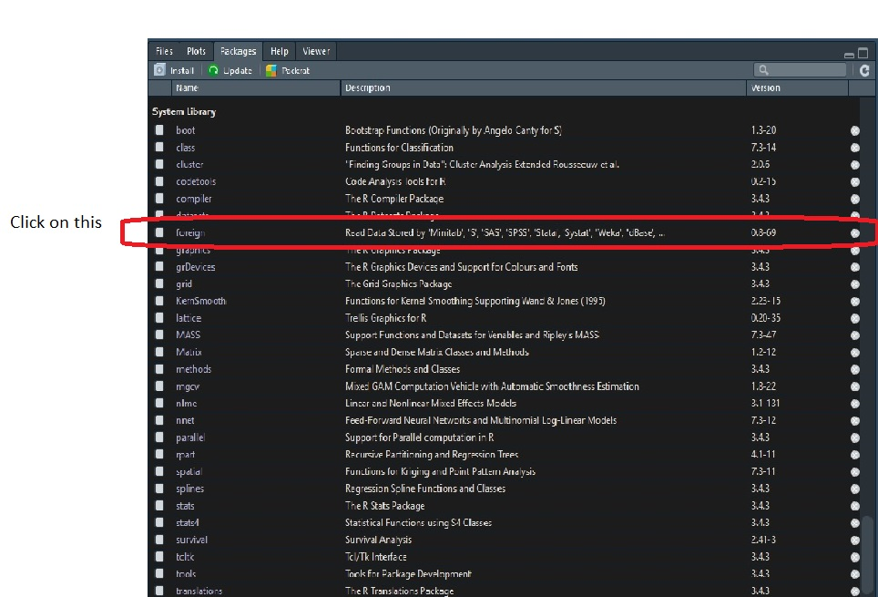

## File Pathways

- Change the working directory
  - getwd() identify the current working directory
  - setwd() changes the working directory pathway
  - NOTE: R use the forward slash (“/”) not the backward slash (“\”) for file pathway
  - The “\” is used to escape R special character
- Use the full pathway for the data file
  - file.choose() is a shortcut to generating the full file path
  - shortened pathway can be used if within subworking directory
  - file name only if in the same working directory
  - html pathway if online

## Read file examples

- Read in the “drinks” data file
- Example: csv file within subworking directory

  ```r
  drinks <- read.csv("../data/drinks.csv", header = TRUE)
  ```

- Example: excel file within subworking directory

  ```r
  library(readxl)
  drinks <- read_excel("../data/drinks_USbirths.xlsx", sheet = "drinks")
  ```

## Export Files

- Example: stata file in different directory

  ```r
  library(foreign)
  write.dta(drinks,"C:/Users/SHong/Desktop/drinks.dta")
  ```

- - specify the R object to be exported
  - specify the file format in the name of the file pathway

## Concepts covered

1. Conceptual framework of data objects
2. Indexing
3. Library packages
4. Read (import) in data
5. Write (export) out data

## Exercises : Coder

- Read in the data file:
  - drinks, or
  - US Births
- Describe the data
  - Some commands to consider…. str, summary, colnames, rownames, length
  - commands you’ve learned in other courses
- Export the data
  - in any file format of your choice
  - must be in a different directory or subdirectory

## Exercises : Reviewer

- Run the code given to you
  - What did you learn from the other person’s code?
  - Were you able to perfom any troubleshooting?
  - What challenges did you experience in reading/running the other person’s code?

## Exercises : Bonus

- Rerun your code for Homework 1
- Save objects in your environment as a list